# hw2

HW2 Yu Wu

```python
import matplotlib
import matplotlib.pyplot as plt
import numpy as np
import scipy
from scipy import stats
matplotlib.rc('figure', figsize = (8, 5))
```

1. Rolling sevens is more probable. Because there are 6X6 = 36 results, only one result is snake eyes. So snake eyes' probability is 1/36. There are 6 results that would sum to 7. 1+6,2+5,3+4,4+3,5+2,6+1. So rolling sevens' probability is 6/36 = 1/6. 1/6 > 1/36, so Rolling sevens is more probable.

2.analytically (math & counting)

sum = (2, 3, 4, 5, 6, 7, 8, 9, 10, 11, 12)

probability = (1/36, 2/36, 3/36, 4/36, 5/36, 6/36, 5/36, 4/36, 3/36, 2/36, 1/36)

2.numerically (computer program)

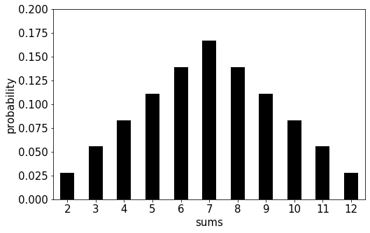

```python
p = np.array([1/6] * 6)
sump = np.convolve(p, p)
plt.xlabel("sums")
plt.ylabel("probability")
plt.xticks(range(2, 13))
plt.ylim(0, 1/5)
plt.vlines(range(2, 13), 0, sump, linewidth = 20);
```

3.

```python
mean = sum(sump * np.arange(2, 13))
variance = sum(sump * (np.arange(2, 13) - mean)**2)
```

```python
mean
```

```
7.0
```

```python
variance
```

```
5.833333333333334
```

4.

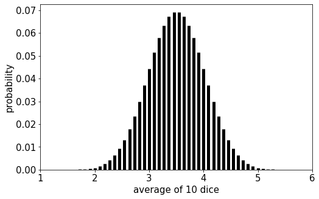

```python
def average(trials, width=5):
    avgp = np.copy(p)
    for i in range(trials):
        avgp = np.convolve(p, avgp)
    plt.xlabel("average of 10 dice")
    plt.ylabel("probability")
    pofavg = np.linspace(1, 6, len(avgp))
    plt.vlines(pofavg, 0, avgp, linewidth = 5);
    plt.xlim(1, 6)
    plt.ylim(0, None)
    return pofavg, avgp
average(10);
```

The average does follow a gaussian distribution. There are peak and wing pattern point it to a gaussian. It will be a better approximation when the sample size increase.

5.

```
(2, 5)
```

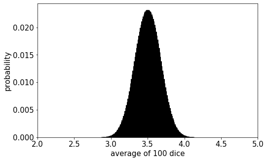

```python
pofavg, avgp = average(100, width=2)
mean = sum(avgp * pofavg)
variance = sum(avgp * (pofavg - mean)**2)
ax = plt.gca()
plt.xlabel("average of 100 dice")
plt.xlim(2, 5)
```

It clearly follows the gaussian distribution, and it's a better approximation. When the sample size increase, the bias will decrease, independent random variables will also decrease.